# ML model development based on Brazil’s Covid-19 dataset

Machine Learning - Individual Assignment

Beatriz Manso

student ID: 21485094

## Description of the data:

https://www.kaggle.com/S%C3%ADrio-Libanes/covid19

- Patient demographic information (03)
- Patient previous grouped diseases (09)
- Blood results (36)
- Vital signs (06)
- Blood gases

In total there are 54 features, expanded when pertinent to the mean, median, max, min, diff and relative diff.

The data is already scaled.

**The goal of this notebook is to develop a ML model to predict if a patient of confirmed COVID-19 case will require admission to the ICU.**

# Set working directory:

```python
#IF WORKING ON JUPITER NOTEBOOK
#import os
#os.chdir("C:/Users/manso/OneDrive - University of West London/MSc Bioinformatics - UWL/4.ML - Machine Learning/Assessments/ML Individual Project")
```

```python
#IF WORKING ON GOOGLE COLAB
from google.colab import drive
drive.mount('/content/drive')
```

```python
#setting working directory
%cd'/content/drive/MyDrive/ML/BM_IndividualAssig'
```

```
/content/drive/MyDrive/ML/BM_IndividualAssig
```

# Installing Specific Packages:

```python
import pandas as pd
import numpy as np

#visualisation
import matplotlib.pyplot as plt
import seaborn as sns

#???? this wasnt used
from sklearn.feature_selection import SelectFromModel
from sklearn.utils import shuffle
from sklearn.model_selection import train_test_split, cross_validate, GridSearchCV  #?
from sklearn.preprocessing import LabelEncoder

# Machine Learning Models
from sklearn.linear_model import LogisticRegression
from sklearn.tree import DecisionTreeClassifier
from sklearn.ensemble import RandomForestClassifier
from sklearn.svm import SVC

# Stratified validation
from sklearn.model_selection import train_test_split
from sklearn.model_selection import cross_validate
from sklearn.model_selection import RepeatedStratifiedKFold

# Evaluation metrics
from sklearn.metrics import accuracy_score
from sklearn.metrics import plot_confusion_matrix
from sklearn.metrics import classification_report
from sklearn.metrics import confusion_matrix

import missingno as msno
%matplotlib inline
```

# Data at First Sight

```python
# Load our dataset
data = pd.read_excel('Kaggle_Sirio_Libanes_ICU_Prediction.xlsx')
pd.set_option('display.max_columns', None)
pd.set_option('display.max_rows', None)
```

```python
#check dimension of data
print('Rows: {} | Columns: {}'.format(data.shape[0], data.shape[1]))
```

```
Rows: 1925 | Columns: 231
```

```python
data.head(10)
```

|  | PATIENT_VISIT_IDENTIFIER | AGE_ABOVE65 | AGE_PERCENTIL | GENDER | DISEASE GROUPING 1 | DISEASE GROUPING 2 | DISEASE GROUPING 3 | DISEASE GROUPING 4 | DISEASE GROUPING 5 | DISEASE GROUPING 6 | HTN | IMMUNOCOMPROMISED | OTHER | ALBUMIN_MEDIAN | ALBUMIN_MEAN | ALBUMIN_MIN | ALBUMIN_MAX | ALBUMIN_DIFF | BE_ARTERIAL_MEDIAN | BE_ARTERIAL_MEAN | BE_ARTERIAL_MIN | BE_ARTERIAL_MAX | BE_ARTERIAL_DIFF | BE_VENOUS_MEDIAN | BE_VENOUS_MEAN | BE_VENOUS_MIN | BE_VENOUS_MAX | BE_VENOUS_DIFF | BIC_ARTERIAL_MEDIAN | … |
| --- | --- | --- | --- | --- | --- | --- | --- | --- | --- | --- | --- | --- | --- | --- | --- | --- | --- | --- | --- | --- | --- | --- | --- | --- | --- | --- | --- | --- | --- | --- |
| 0 | 0 | 1 | 60th | 0 | 0.0 | 0.0 | 0.0 | 0.0 | 1.0 | 1.0 | 0.0 | 0.0 | 1.0 | NaN | NaN | NaN | NaN | NaN | NaN | NaN | NaN | NaN | NaN | NaN | NaN | NaN | NaN | NaN | NaN | … |
| 1 | 0 | 1 | 60th | 0 | 0.0 | 0.0 | 0.0 | 0.0 | 1.0 | 1.0 | 0.0 | 0.0 | 1.0 | NaN | NaN | NaN | NaN | NaN | NaN | NaN | NaN | NaN | NaN | NaN | NaN | NaN | NaN | NaN | NaN | … |
| 2 | 0 | 1 | 60th | 0 | 0.0 | 0.0 | 0.0 | 0.0 | 1.0 | 1.0 | 0.0 | 0.0 | 1.0 | 0.605263 | 0.605263 | 0.605263 | 0.605263 | -1.0 | -1.000000 | -1.000000 | -1.000000 | -1.000000 | -1.0 | -1.000000 | -1.000000 | -1.000000 | -1.000000 | -1.0 | -0.317073 | … |
| 3 | 0 | 1 | 60th | 0 | 0.0 | 0.0 | 0.0 | 0.0 | 1.0 | 1.0 | 0.0 | 0.0 | 1.0 | NaN | NaN | NaN | NaN | NaN | NaN | NaN | NaN | NaN | NaN | NaN | NaN | NaN | NaN | NaN | NaN | … |
| 4 | 0 | 1 | 60th | 0 | 0.0 | 0.0 | 0.0 | 0.0 | 1.0 | 1.0 | 0.0 | 0.0 | 1.0 | 0.000000 | 0.000000 | 0.000000 | 0.000000 | -1.0 | -0.871658 | -0.871658 | -0.871658 | -0.871658 | -1.0 | -0.863874 | -0.863874 | -0.863874 | -0.863874 | -1.0 | -0.317073 | … |
| 5 | 1 | 1 | 90th | 1 | 0.0 | 0.0 | 0.0 | 0.0 | 0.0 | 0.0 | 1.0 | 1.0 | 1.0 | NaN | NaN | NaN | NaN | NaN | NaN | NaN | NaN | NaN | NaN | NaN | NaN | NaN | NaN | NaN | NaN | … |
| 6 | 1 | 1 | 90th | 1 | 0.0 | 0.0 | 0.0 | 0.0 | 0.0 | 0.0 | 1.0 | 1.0 | 1.0 | -0.210526 | -0.210526 | -0.210526 | -0.210526 | -1.0 | -1.000000 | -1.000000 | -1.000000 | -1.000000 | -1.0 | -1.000000 | -1.000000 | -1.000000 | -1.000000 | -1.0 | -0.317073 | … |
| 7 | 1 | 1 | 90th | 1 | 0.0 | 0.0 | 0.0 | 0.0 | 0.0 | 0.0 | 1.0 | 1.0 | 1.0 | NaN | NaN | NaN | NaN | NaN | NaN | NaN | NaN | NaN | NaN | NaN | NaN | NaN | NaN | NaN | NaN | … |
| 8 | 1 | 1 | 90th | 1 | 0.0 | 0.0 | 0.0 | 0.0 | 0.0 | 0.0 | 1.0 | 1.0 | 1.0 | 0.605263 | 0.605263 | 0.605263 | 0.605263 | -1.0 | -0.839572 | -0.839572 | -0.839572 | -0.839572 | -1.0 | -1.000000 | -1.000000 | -1.000000 | -1.000000 | -1.0 | -0.219512 | … |
| 9 | 1 | 1 | 90th | 1 | 0.0 | 0.0 | 0.0 | 0.0 | 1.0 | 0.0 | 1.0 | 1.0 | 1.0 | 0.605263 | 0.605263 | 0.605263 | 0.605263 | -1.0 | -0.914439 | -0.914439 | -0.914439 | -0.914439 | -1.0 | -0.916230 | -0.916230 | -0.916230 | -0.916230 | -1.0 | -0.268293 | … |

Obs:

- The data has been anonymised regarding the disseases. So, we have disease goups from 1 to 6 but we do not know which specific disease it is.
- Just from a quick glace at our data, in the first 10 rows, we can already see that there are a lot of NaN values in our dataset.

```python
data.tail()
```

|  | PATIENT_VISIT_IDENTIFIER | AGE_ABOVE65 | AGE_PERCENTIL | GENDER | DISEASE GROUPING 1 | DISEASE GROUPING 2 | DISEASE GROUPING 3 | DISEASE GROUPING 4 | DISEASE GROUPING 5 | DISEASE GROUPING 6 | HTN | IMMUNOCOMPROMISED | OTHER | ALBUMIN_MEDIAN | ALBUMIN_MEAN | ALBUMIN_MIN | ALBUMIN_MAX | ALBUMIN_DIFF | BE_ARTERIAL_MEDIAN | BE_ARTERIAL_MEAN | BE_ARTERIAL_MIN | BE_ARTERIAL_MAX | BE_ARTERIAL_DIFF | BE_VENOUS_MEDIAN | BE_VENOUS_MEAN | BE_VENOUS_MIN | BE_VENOUS_MAX | BE_VENOUS_DIFF | BIC_ARTERIAL_MEDIAN | … |
| --- | --- | --- | --- | --- | --- | --- | --- | --- | --- | --- | --- | --- | --- | --- | --- | --- | --- | --- | --- | --- | --- | --- | --- | --- | --- | --- | --- | --- | --- | --- |
| 1920 | 384 | 0 | 50th | 1 | 0.0 | 0.0 | 0.0 | 0.0 | 0.0 | 0.0 | 0.0 | 0.0 | 1.0 | NaN | NaN | NaN | NaN | NaN | NaN | NaN | NaN | NaN | NaN | NaN | NaN | NaN | NaN | NaN | NaN | … |
| 1921 | 384 | 0 | 50th | 1 | 0.0 | 0.0 | 0.0 | 0.0 | 0.0 | 0.0 | 0.0 | 0.0 | 1.0 | 0.605263 | 0.605263 | 0.605263 | 0.605263 | -1.0 | -1.0 | -1.0 | -1.0 | -1.0 | -1.0 | -0.717277 | -0.717277 | -0.717277 | -0.717277 | -1.0 | -0.317073 | … |
| 1922 | 384 | 0 | 50th | 1 | 0.0 | 0.0 | 0.0 | 0.0 | 0.0 | 0.0 | 0.0 | 0.0 | 1.0 | NaN | NaN | NaN | NaN | NaN | NaN | NaN | NaN | NaN | NaN | NaN | NaN | NaN | NaN | NaN | NaN | … |
| 1923 | 384 | 0 | 50th | 1 | 0.0 | 0.0 | 0.0 | 0.0 | 0.0 | 0.0 | 0.0 | 0.0 | 1.0 | NaN | NaN | NaN | NaN | NaN | NaN | NaN | NaN | NaN | NaN | NaN | NaN | NaN | NaN | NaN | NaN | … |
| 1924 | 384 | 0 | 50th | 1 | 0.0 | 0.0 | 1.0 | 0.0 | 0.0 | 0.0 | 0.0 | 0.0 | 1.0 | 0.605263 | 0.605263 | 0.605263 | 0.605263 | -1.0 | -1.0 | -1.0 | -1.0 | -1.0 | -1.0 | -1.000000 | -1.000000 | -1.000000 | -1.000000 | -1.0 | -0.317073 | … |

```python
#Looking at statistics about our data
data.describe()
```

|  | PATIENT_VISIT_IDENTIFIER | AGE_ABOVE65 | GENDER | DISEASE GROUPING 1 | DISEASE GROUPING 2 | DISEASE GROUPING 3 | DISEASE GROUPING 4 | DISEASE GROUPING 5 | DISEASE GROUPING 6 | HTN | IMMUNOCOMPROMISED | OTHER | ALBUMIN_MEDIAN | ALBUMIN_MEAN | ALBUMIN_MIN | ALBUMIN_MAX | ALBUMIN_DIFF | BE_ARTERIAL_MEDIAN | BE_ARTERIAL_MEAN | BE_ARTERIAL_MIN | BE_ARTERIAL_MAX | BE_ARTERIAL_DIFF | BE_VENOUS_MEDIAN | BE_VENOUS_MEAN | BE_VENOUS_MIN | BE_VENOUS_MAX | BE_VENOUS_DIFF | BIC_ARTERIAL_MEDIAN | BIC_ARTERIAL_MEAN | … |
| --- | --- | --- | --- | --- | --- | --- | --- | --- | --- | --- | --- | --- | --- | --- | --- | --- | --- | --- | --- | --- | --- | --- | --- | --- | --- | --- | --- | --- | --- | --- |
| count | 1925.000000 | 1925.000000 | 1925.000000 | 1920.000000 | 1920.000000 | 1920.000000 | 1920.000000 | 1920.000000 | 1920.000000 | 1920.000000 | 1920.000000 | 1920.000000 | 821.000000 | 821.000000 | 821.000000 | 821.000000 | 821.0 | 821.000000 | 821.000000 | 821.000000 | 821.000000 | 821.0 | 821.000000 | 821.000000 | 821.000000 | 821.000000 | 821.0 | 821.000000 | 821.000000 | … |
| mean | 192.000000 | 0.467532 | 0.368831 | 0.108333 | 0.028125 | 0.097917 | 0.019792 | 0.128125 | 0.046875 | 0.213021 | 0.158333 | 0.809896 | 0.528527 | 0.528527 | 0.528527 | 0.528527 | -1.0 | -0.963433 | -0.963433 | -0.963433 | -0.963433 | -1.0 | -0.931121 | -0.931121 | -0.931121 | -0.931121 | -1.0 | -0.310924 | -0.310924 | … |
| std | 111.168431 | 0.499074 | 0.482613 | 0.310882 | 0.165373 | 0.297279 | 0.139320 | 0.334316 | 0.211426 | 0.409549 | 0.365148 | 0.392485 | 0.224100 | 0.224100 | 0.224100 | 0.224100 | 0.0 | 0.160870 | 0.160870 | 0.160870 | 0.160870 | 0.0 | 0.169509 | 0.169509 | 0.169509 | 0.169509 | 0.0 | 0.100256 | 0.100256 | … |
| min | 0.000000 | 0.000000 | 0.000000 | 0.000000 | 0.000000 | 0.000000 | 0.000000 | 0.000000 | 0.000000 | 0.000000 | 0.000000 | 0.000000 | -1.000000 | -1.000000 | -1.000000 | -1.000000 | -1.0 | -1.000000 | -1.000000 | -1.000000 | -1.000000 | -1.0 | -1.000000 | -1.000000 | -1.000000 | -1.000000 | -1.0 | -1.000000 | -1.000000 | … |
| 25% | 96.000000 | 0.000000 | 0.000000 | 0.000000 | 0.000000 | 0.000000 | 0.000000 | 0.000000 | 0.000000 | 0.000000 | 0.000000 | 1.000000 | 0.605263 | 0.605263 | 0.605263 | 0.605263 | -1.0 | -1.000000 | -1.000000 | -1.000000 | -1.000000 | -1.0 | -1.000000 | -1.000000 | -1.000000 | -1.000000 | -1.0 | -0.317073 | -0.317073 | … |
| 50% | 192.000000 | 0.000000 | 0.000000 | 0.000000 | 0.000000 | 0.000000 | 0.000000 | 0.000000 | 0.000000 | 0.000000 | 0.000000 | 1.000000 | 0.605263 | 0.605263 | 0.605263 | 0.605263 | -1.0 | -1.000000 | -1.000000 | -1.000000 | -1.000000 | -1.0 | -1.000000 | -1.000000 | -1.000000 | -1.000000 | -1.0 | -0.317073 | -0.317073 | … |
| 75% | 288.000000 | 1.000000 | 1.000000 | 0.000000 | 0.000000 | 0.000000 | 0.000000 | 0.000000 | 0.000000 | 0.000000 | 0.000000 | 1.000000 | 0.605263 | 0.605263 | 0.605263 | 0.605263 | -1.0 | -1.000000 | -1.000000 | -1.000000 | -1.000000 | -1.0 | -0.958115 | -0.958115 | -0.958115 | -0.958115 | -1.0 | -0.317073 | -0.317073 | … |
| max | 384.000000 | 1.000000 | 1.000000 | 1.000000 | 1.000000 | 1.000000 | 1.000000 | 1.000000 | 1.000000 | 1.000000 | 1.000000 | 1.000000 | 1.000000 | 1.000000 | 1.000000 | 1.000000 | -1.0 | 1.000000 | 1.000000 | 1.000000 | 1.000000 | -1.0 | 1.000000 | 1.000000 | 1.000000 | 1.000000 | -1.0 | 1.000000 | 1.000000 | … |

```python
#Check class, dtype, number of columns and rows
data.info()
```

```
<class 'pandas.core.frame.DataFrame'>
RangeIndex: 1925 entries, 0 to 1924
Columns: 231 entries, PATIENT_VISIT_IDENTIFIER to ICU
dtypes: float64(225), int64(4), object(2)
memory usage: 3.4+ MB
```

```python
# check what are the 2 categorical features
cat_cols = data.select_dtypes(include=['object']).columns
num_cols = data.select_dtypes(exclude=['object']).columns

cat_cols
```

```
Index(['AGE_PERCENTIL', 'WINDOW'], dtype='object')
```

```python
# Check total number of patients in our data

sum_patients=data['PATIENT_VISIT_IDENTIFIER'].nunique()
print('There are {} patients in the dataset'.format(sum_patients))
```

```
There are 385 patients in the dataset
```

```python
data['ICU'].value_counts()
```

```
0    1410
1     515
Name: ICU, dtype: int64
```

```python
data.groupby('PATIENT_VISIT_IDENTIFIER').agg({'ICU': max}).value_counts()
```

```
ICU
1      195
0      190
dtype: int64
```

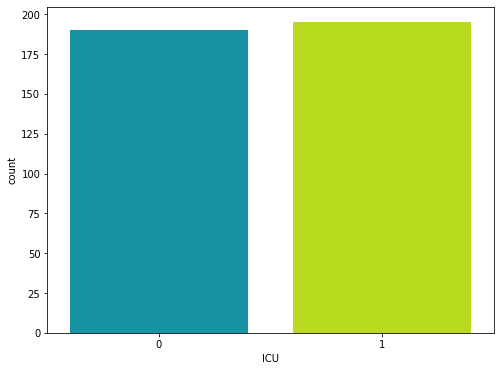

```python
# Plot ICU cases
fig, ax = plt.subplots(figsize=(8,6))
sns.countplot(data = data.groupby('PATIENT_VISIT_IDENTIFIER').agg({'ICU': max}), x='ICU', ax=ax, palette='nipy_spectral')
```

Between the 385 patients in our dataset, we can se that 195 patients were admitted to the ICU and 190 weren't. We can consider this distribution of data close enough and our target variable is well balanced.

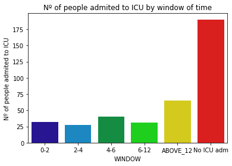

```python
ICU_table = data.pivot(index="PATIENT_VISIT_IDENTIFIER", columns="WINDOW", values="ICU")
ICU_table["Type"] = ICU_table.sum(axis=1)

dic = {5: "0-2", 4: "2-4", 3: "4-6", 2: "6-12", 1:"ABOVE_12", 0: "No ICU adm"}

ICU_table["WINDOW"] = ICU_table["Type"].replace(dic)

temp = ICU_table.groupby("WINDOW").count()

sns.barplot(data = temp.reset_index(), x = "WINDOW", y ="ABOVE_12", palette='nipy_spectral')

plt.title("Nº of people admited to ICU by window of time")
plt.ylabel('Nº of people admited to ICU')
plt.show()
```

Obs:

The graph above shows the number of admissions to the ICU by window of time.

From the people that are admited in the ICU, the highest percentage is after 12 hours of being admitted to the hospital.

# Metadata

```python
mdata = []
for feature in data.columns:
    # Defining the role
    if feature == 'ICU':
        role = 'target'
    elif feature == 'PATIENT_VISIT_IDENTIFIER':
        role = 'id'
    else:
        role = 'input'

    # Defining the level
    if feature == 'PATIENT_VISIT_IDENTIFIER' or data[feature].dtype == object:
        level = 'nominal'
    elif feature=='AGE_ABOVE65' or  feature=='GENDER' or feature=='DISEASE GROUPING 1' or  feature=='DISEASE GROUPING 2' or  feature=='DISEASE GROUPING 3'  or   feature=='DISEASE GROUPING 4' or  feature=='DISEASE GROUPING 5' or  feature=='DISEASE GROUPING 6' or  feature=='HTN' or  feature=='IMMUNOCOMPROMISED' or  feature=='OTHER' or  feature=='ICU':
        level = 'binary'
    elif data[feature].dtype == float:
        level = 'interval'
    else:
        level = 'ordinal'


    # Initialize keep to True for all variables except for id
    keep = True
    if feature == 'Id':
        keep = False

    # Defining the data type
    dtype = data[feature].dtype


    # Creating a Dict that contains all the metadata for the variable
    feature_dict = {
        'varname': feature,
        'role': role,
        'level': level,
        'keep': keep,
        'dtype': dtype
    }
    mdata.append(feature_dict)

meta1 = pd.DataFrame(mdata, columns=['varname', 'role', 'level', 'keep', 'dtype'])
meta1.set_index('varname', inplace=True)
meta1
```

| varname | role | level | keep | dtype |
| --- | --- | --- | --- | --- |
| PATIENT_VISIT_IDENTIFIER | id | nominal | True | int64 |
| AGE_ABOVE65 | input | binary | True | int64 |
| AGE_PERCENTIL | input | nominal | True | object |
| GENDER | input | binary | True | int64 |
| DISEASE GROUPING 1 | input | binary | True | float64 |
| DISEASE GROUPING 2 | input | binary | True | float64 |
| DISEASE GROUPING 3 | input | binary | True | float64 |
| DISEASE GROUPING 4 | input | binary | True | float64 |
| DISEASE GROUPING 5 | input | binary | True | float64 |
| DISEASE GROUPING 6 | input | binary | True | float64 |
| HTN | input | binary | True | float64 |
| IMMUNOCOMPROMISED | input | binary | True | float64 |
| OTHER | input | binary | True | float64 |
| ALBUMIN_MEDIAN | input | interval | True | float64 |
| ALBUMIN_MEAN | input | interval | True | float64 |
| ALBUMIN_MIN | input | interval | True | float64 |
| ALBUMIN_MAX | input | interval | True | float64 |
| ALBUMIN_DIFF | input | interval | True | float64 |
| BE_ARTERIAL_MEDIAN | input | interval | True | float64 |
| BE_ARTERIAL_MEAN | input | interval | True | float64 |
| BE_ARTERIAL_MIN | input | interval | True | float64 |
| BE_ARTERIAL_MAX | input | interval | True | float64 |
| BE_ARTERIAL_DIFF | input | interval | True | float64 |
| BE_VENOUS_MEDIAN | input | interval | True | float64 |
| BE_VENOUS_MEAN | input | interval | True | float64 |
| BE_VENOUS_MIN | input | interval | True | float64 |
| BE_VENOUS_MAX | input | interval | True | float64 |
| BE_VENOUS_DIFF | input | interval | True | float64 |
| BIC_ARTERIAL_MEDIAN | input | interval | True | float64 |
| BIC_ARTERIAL_MEAN | input | interval | True | float64 |

[output cut: 201 more lines]

```python
mdata = []
for feature in data.columns:
    # Defining the role
    if feature == 'ICU':
        use = 'target'
    elif feature == 'PATIENT_VISIT_IDENTIFIER':
        use = 'id'
    else:
        use = 'input'

    # Defining the type
    if feature=='AGE_ABOVE65' or  feature=='GENDER' or feature=='DISEASE GROUPING 1' or  feature=='DISEASE GROUPING 2' or  feature=='DISEASE GROUPING 3'  or   feature=='DISEASE GROUPING 4' or  feature=='DISEASE GROUPING 5' or  feature=='DISEASE GROUPING 6' or  feature=='HTN' or  feature=='IMMUNOCOMPROMISED' or  feature=='OTHER' or  feature=='ICU':
        type = 'binary'
    elif feature == 'id' or data[feature].dtype == object:
        type = 'categorical'
    elif data[feature].dtype == float or isinstance(data[feature].dtype, float):
        type = 'real'
    else:
        type = 'integer'

    # Initialize preserve to True for all variables except for id
    preserve = True
    if feature == 'PATIENT_VISIT_IDENTIFIER':
        preserve = False

    # Defining the data type
    dtype = data[feature].dtype

    category = 'none'

    # Defining the category
    if feature == 'PATIENT_VISIT_IDENTIFIER':
        category = 'id'
    elif feature == 'AGE_ABOVE65' or feature == 'AGE_PERCENTIL':
        category = 'age'
    elif feature == 'ICU':
        category = 'target'
    elif 'DISEASE' in feature or feature=='HTN' or feature=='OTHER' or feature =='IMMUNOCOMPROMISED':
        category = 'disease'
    elif feature=='GENDER':
        category = 'gender'
    else :
        category = 'vital signs and blood results'


    # Creating a Dict that contains all the metadata for the variable
    feature_dictionary = {
        'varname': feature,
        'use': use,
        'type': type,
        'preserve': preserve,
        'dtype': dtype,
        'category' : category
    }
    mdata.append(feature_dictionary)

meta2 = pd.DataFrame(mdata, columns=['varname', 'use', 'type', 'preserve', 'dtype', 'category'])
meta2.set_index('varname', inplace=True)
meta2
```

| varname | use | type | preserve | dtype | category |
| --- | --- | --- | --- | --- | --- |
| PATIENT_VISIT_IDENTIFIER | id | integer | False | int64 | id |
| AGE_ABOVE65 | input | binary | True | int64 | age |
| AGE_PERCENTIL | input | categorical | True | object | age |
| GENDER | input | binary | True | int64 | gender |
| DISEASE GROUPING 1 | input | binary | True | float64 | disease |
| DISEASE GROUPING 2 | input | binary | True | float64 | disease |
| DISEASE GROUPING 3 | input | binary | True | float64 | disease |
| DISEASE GROUPING 4 | input | binary | True | float64 | disease |
| DISEASE GROUPING 5 | input | binary | True | float64 | disease |
| DISEASE GROUPING 6 | input | binary | True | float64 | disease |
| HTN | input | binary | True | float64 | disease |
| IMMUNOCOMPROMISED | input | binary | True | float64 | disease |
| OTHER | input | binary | True | float64 | disease |
| ALBUMIN_MEDIAN | input | real | True | float64 | vital signs and blood results |
| ALBUMIN_MEAN | input | real | True | float64 | vital signs and blood results |
| ALBUMIN_MIN | input | real | True | float64 | vital signs and blood results |
| ALBUMIN_MAX | input | real | True | float64 | vital signs and blood results |
| ALBUMIN_DIFF | input | real | True | float64 | vital signs and blood results |
| BE_ARTERIAL_MEDIAN | input | real | True | float64 | vital signs and blood results |
| BE_ARTERIAL_MEAN | input | real | True | float64 | vital signs and blood results |
| BE_ARTERIAL_MIN | input | real | True | float64 | vital signs and blood results |
| BE_ARTERIAL_MAX | input | real | True | float64 | vital signs and blood results |
| BE_ARTERIAL_DIFF | input | real | True | float64 | vital signs and blood results |
| BE_VENOUS_MEDIAN | input | real | True | float64 | vital signs and blood results |
| BE_VENOUS_MEAN | input | real | True | float64 | vital signs and blood results |
| BE_VENOUS_MIN | input | real | True | float64 | vital signs and blood results |
| BE_VENOUS_MAX | input | real | True | float64 | vital signs and blood results |
| BE_VENOUS_DIFF | input | real | True | float64 | vital signs and blood results |
| BIC_ARTERIAL_MEDIAN | input | real | True | float64 | vital signs and blood results |
| BIC_ARTERIAL_MEAN | input | real | True | float64 | vital signs and blood results |

[output cut: 201 more lines]

```python
meta2[(meta2.type == 'binary') & (meta2.preserve)].index
```

```
Index(['AGE_ABOVE65', 'GENDER', 'DISEASE GROUPING 1', 'DISEASE GROUPING 2',
       'DISEASE GROUPING 3', 'DISEASE GROUPING 4', 'DISEASE GROUPING 5',
       'DISEASE GROUPING 6', 'HTN', 'IMMUNOCOMPROMISED', 'OTHER', 'ICU'],
      dtype='object', name='varname')
```

```python
pd.DataFrame({'count' : meta2.groupby(['category'])['category'].size()}).reset_index()
```

|  | category | count |
| --- | --- | --- |
| 0 | age | 2 |
| 1 | disease | 9 |
| 2 | gender | 1 |
| 3 | id | 1 |
| 4 | target | 1 |
| 5 | vital signs and blood results | 217 |

# Exploratory Data Analysis (EDA)

## Data Quality Issues

### Data Duplications

```python
duplicates=data.drop_duplicates()
duplicates.shape
```

```
(1925, 231)
```

Obs: There are no duplicates in our data.

### Missing Values

```python
def _impute_missing_data(data):
    return data.replace(-1, np.nan)

data_miss = _impute_missing_data(data)

print('NaN values =', data.isnull().sum().sum())
print("""""")

vars_with_missing = []

for feature in data.columns:
    missings = data[feature].isna().sum()

    if missings > 0 :
        vars_with_missing.append(feature)
        missings_perc = missings / data.shape[0]

        print('Variable {} has {} records ({:.2%}) with missing values.'.format(feature, missings, missings_perc))
print('In total, there are {} variables with missing values'.format(len(vars_with_missing)))
```

```
NaN values = 223863

Variable DISEASE GROUPING 1 has 5 records (0.26%) with missing values.
Variable DISEASE GROUPING 2 has 5 records (0.26%) with missing values.
Variable DISEASE GROUPING 3 has 5 records (0.26%) with missing values.
Variable DISEASE GROUPING 4 has 5 records (0.26%) with missing values.
Variable DISEASE GROUPING 5 has 5 records (0.26%) with missing values.
Variable DISEASE GROUPING 6 has 5 records (0.26%) with missing values.
Variable HTN has 5 records (0.26%) with missing values.
Variable IMMUNOCOMPROMISED has 5 records (0.26%) with missing values.
Variable OTHER has 5 records (0.26%) with missing values.
Variable ALBUMIN_MEDIAN has 1104 records (57.35%) with missing values.
Variable ALBUMIN_MEAN has 1104 records (57.35%) with missing values.
Variable ALBUMIN_MIN has 1104 records (57.35%) with missing values.
Variable ALBUMIN_MAX has 1104 records (57.35%) with missing values.
Variable ALBUMIN_DIFF has 1104 records (57.35%) with missing values.
Variable BE_ARTERIAL_MEDIAN has 1104 records (57.35%) with missing values.
Variable BE_ARTERIAL_MEAN has 1104 records (57.35%) with missing values.
Variable BE_ARTERIAL_MIN has 1104 records (57.35%) with missing values.
Variable BE_ARTERIAL_MAX has 1104 records (57.35%) with missing values.
Variable BE_ARTERIAL_DIFF has 1104 records (57.35%) with missing values.
Variable BE_VENOUS_MEDIAN has 1104 records (57.35%) with missing values.
Variable BE_VENOUS_MEAN has 1104 records (57.35%) with missing values.
Variable BE_VENOUS_MIN has 1104 records (57.35%) with missing values.
Variable BE_VENOUS_MAX has 1104 records (57.35%) with missing values.
Variable BE_VENOUS_DIFF has 1104 records (57.35%) with missing values.
Variable BIC_ARTERIAL_MEDIAN has 1104 records (57.35%) with missing values.
Variable BIC_ARTERIAL_MEAN has 1104 records (57.35%) with missing values.
Variable BIC_ARTERIAL_MIN has 1104 records (57.35%) with missing values.
Variable BIC_ARTERIAL_MAX has 1104 records (57.35%) with missing values.
Variable BIC_ARTERIAL_DIFF has 1104 records (57.35%) with missing values.
Variable BIC_VENOUS_MEDIAN has 1104 records (57.35%) with missing values.
Variable BIC_VENOUS_MEAN has 1104 records (57.35%) with missing values.
Variable BIC_VENOUS_MIN has 1104 records (57.35%) with missing values.
Variable BIC_VENOUS_MAX has 1104 records (57.35%) with missing values.
Variable BIC_VENOUS_DIFF has 1104 records (57.35%) with missing values.
Variable BILLIRUBIN_MEDIAN has 1104 records (57.35%) with missing values.
Variable BILLIRUBIN_MEAN has 1104 records (57.35%) with missing values.
Variable BILLIRUBIN_MIN has 1104 records (57.35%) with missing values.
Variable BILLIRUBIN_MAX has 1104 records (57.35%) with missing values.
```

[output cut: 173 more lines]

```
Variable TEMPERATURE_MAX has 694 records (36.05%) with missing values.
Variable OXYGEN_SATURATION_MAX has 686 records (35.64%) with missing values.
Variable BLOODPRESSURE_DIASTOLIC_DIFF has 685 records (35.58%) with missing values.
Variable BLOODPRESSURE_SISTOLIC_DIFF has 685 records (35.58%) with missing values.
Variable HEART_RATE_DIFF has 685 records (35.58%) with missing values.
Variable RESPIRATORY_RATE_DIFF has 748 records (38.86%) with missing values.
Variable TEMPERATURE_DIFF has 694 records (36.05%) with missing values.
Variable OXYGEN_SATURATION_DIFF has 686 records (35.64%) with missing values.
Variable BLOODPRESSURE_DIASTOLIC_DIFF_REL has 685 records (35.58%) with missing values.
Variable BLOODPRESSURE_SISTOLIC_DIFF_REL has 685 records (35.58%) with missing values.
Variable HEART_RATE_DIFF_REL has 685 records (35.58%) with missing values.
Variable RESPIRATORY_RATE_DIFF_REL has 748 records (38.86%) with missing values.
Variable TEMPERATURE_DIFF_REL has 694 records (36.05%) with missing values.
Variable OXYGEN_SATURATION_DIFF_REL has 686 records (35.64%) with missing values.
In total, there are 225 variables with missing values
```

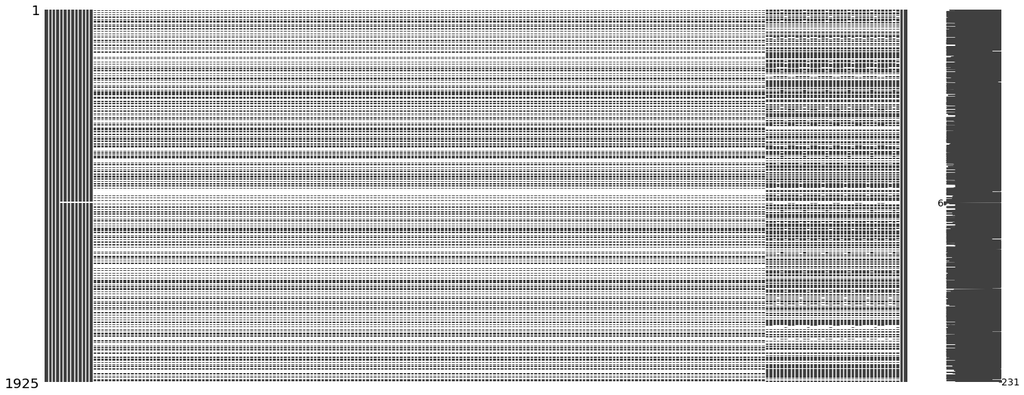

```python
msno.matrix(data)
```

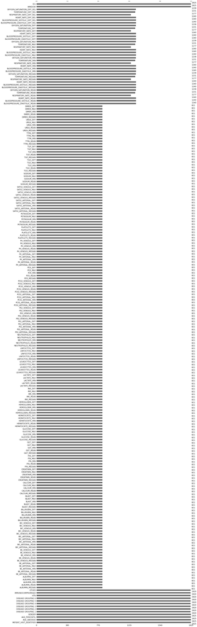

```python
msno.bar(data)
```

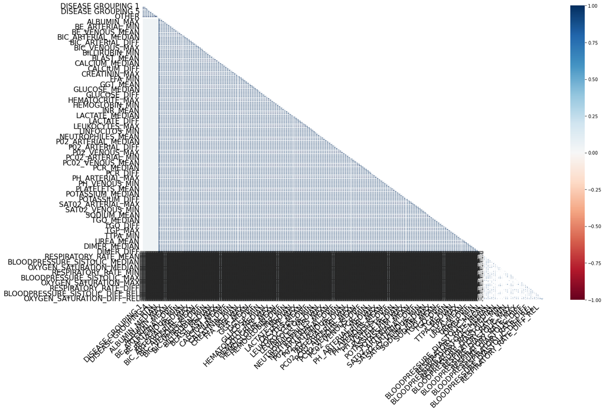

```python
msno.heatmap(data)
```

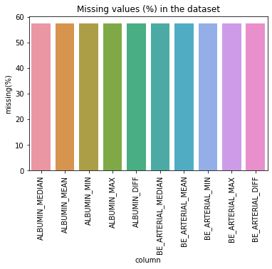

```python
df_missing_data = pd.DataFrame({'column':data.columns, 'missing(%)':((data.isna()).sum()/data.shape[0])*100})

df_missing_data_nl = df_missing_data.nlargest(10, 'missing(%)')

sns.set_palette(sns.color_palette('nipy_spectral'))
sns.barplot(data=df_missing_data_nl, x='column', y='missing(%)',  )
plt.title('Missing values (%) in the dataset')
locs, labels = plt.xticks()
plt.setp(labels, rotation=90)
plt.show()
```

Obs: We can see that the is a huge percentage of missing data in the dataset.

There are 225 variables with missing values and in total, 223863 NaN values.

Missing values in medical data is a common issue. However, according to the outhors of the dataset, we can assume the patients that don't have a measurement recorded are clinically stable and there is a possibility that they have vital signs and blood labs similar to neighboring windows. Therefore, we can deal with missing values by filling them using the next or previous entry, in the data preparation step.

## Univariate Exploration

### Binary Features

```python
var = meta2[(meta2.type == 'binary') & (meta2.preserve)].index
data[var].describe()
```

|  | AGE_ABOVE65 | GENDER | DISEASE GROUPING 1 | DISEASE GROUPING 2 | DISEASE GROUPING 3 | DISEASE GROUPING 4 | DISEASE GROUPING 5 | DISEASE GROUPING 6 | HTN | IMMUNOCOMPROMISED | OTHER | ICU |
| --- | --- | --- | --- | --- | --- | --- | --- | --- | --- | --- | --- | --- |
| count | 1925.000000 | 1925.000000 | 1920.000000 | 1920.000000 | 1920.000000 | 1920.000000 | 1920.000000 | 1920.000000 | 1920.000000 | 1920.000000 | 1920.000000 | 1925.000000 |
| mean | 0.467532 | 0.368831 | 0.108333 | 0.028125 | 0.097917 | 0.019792 | 0.128125 | 0.046875 | 0.213021 | 0.158333 | 0.809896 | 0.267532 |
| std | 0.499074 | 0.482613 | 0.310882 | 0.165373 | 0.297279 | 0.139320 | 0.334316 | 0.211426 | 0.409549 | 0.365148 | 0.392485 | 0.442787 |
| min | 0.000000 | 0.000000 | 0.000000 | 0.000000 | 0.000000 | 0.000000 | 0.000000 | 0.000000 | 0.000000 | 0.000000 | 0.000000 | 0.000000 |
| 25% | 0.000000 | 0.000000 | 0.000000 | 0.000000 | 0.000000 | 0.000000 | 0.000000 | 0.000000 | 0.000000 | 0.000000 | 1.000000 | 0.000000 |
| 50% | 0.000000 | 0.000000 | 0.000000 | 0.000000 | 0.000000 | 0.000000 | 0.000000 | 0.000000 | 0.000000 | 0.000000 | 1.000000 | 0.000000 |
| 75% | 1.000000 | 1.000000 | 0.000000 | 0.000000 | 0.000000 | 0.000000 | 0.000000 | 0.000000 | 0.000000 | 0.000000 | 1.000000 | 1.000000 |
| max | 1.000000 | 1.000000 | 1.000000 | 1.000000 | 1.000000 | 1.000000 | 1.000000 | 1.000000 | 1.000000 | 1.000000 | 1.000000 | 1.000000 |

Obs:

- We can see that the gender variable is strongly imbalanced. There are more males in the dataset than females.

(From the discussion section in the kaggle competition there is a discussion that explains that 0 values in the gender variable represent males while 1's represent females).

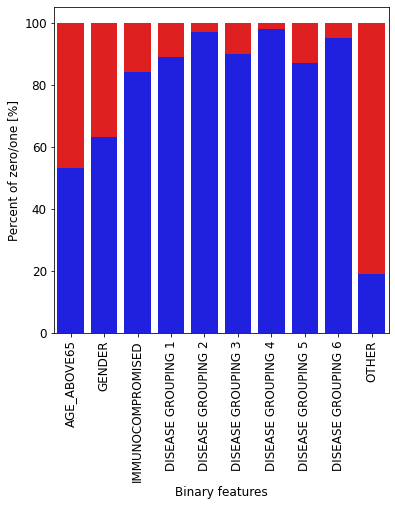

```python
binary = ['AGE_ABOVE65', 'GENDER', 'IMMUNOCOMPROMISED',
 'DISEASE GROUPING 1', 'DISEASE GROUPING 2',
 'DISEASE GROUPING 3', 'DISEASE GROUPING 4',
 'DISEASE GROUPING 5', 'DISEASE GROUPING 6', 'OTHER']

zero_list = []
one_list = []

for col in binary:
    zero_list.append((data[col]==0).sum()/data.shape[0]*100)
    one_list.append((data[col]==1).sum()/data.shape[0]*100)
plt.figure()
fig, ax = plt.subplots(figsize=(6,6))

# Bar plot
p1 = sns.barplot(ax=ax, x=binary, y=zero_list, color="blue")
p2 = sns.barplot(ax=ax, x=binary, y=one_list, bottom= zero_list, color="red")
plt.ylabel('Percent of zero/one [%]', fontsize=12)
plt.xlabel('Binary features', fontsize=12)
locs, labels = plt.xticks()
plt.setp(labels, rotation=90)
plt.tick_params(axis='both', which='major', labelsize=12)
plt.show();
```

```
Males: 243.0
Females: 142.0
```

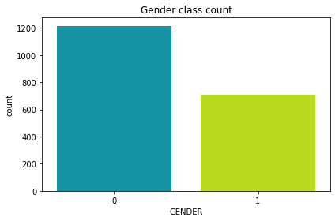

```python
#Plot gender distribution
plt.title('Gender class count')
sns.countplot(data['GENDER'], palette='nipy_spectral' )
plt.tight_layout()

# count and print nº of male and female patients
class_1 = len(data[data['GENDER']==1])/5
class_0 = len(data[data['GENDER']==0])/5

print('Males: {}'.format(class_0))
print('Females: {}'.format(class_1))
```

In our dataset there are 243 males and 142 females.

```python
disease = data[['DISEASE GROUPING 1', 'DISEASE GROUPING 2',
                             'DISEASE GROUPING 3', 'DISEASE GROUPING 4',
                             'DISEASE GROUPING 5', 'DISEASE GROUPING 6', 'HTN',
                             'IMMUNOCOMPROMISED', 'OTHER', 'ICU']]
```

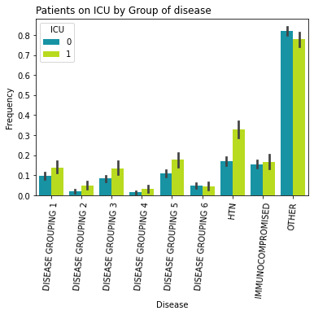

```python
sns.barplot(x='variable', y='value', data=disease.melt(id_vars='ICU'),
            hue='ICU', palette='nipy_spectral')
plt.title('Patients on ICU by Group of disease', loc='left')
plt.ylabel('Frequency')
plt.xlabel('Disease')
plt.xticks(rotation=85);
```

### Categorical features

```python
#Cardinality of data
var = meta2[(meta2.type == 'categorical') & (meta2.preserve)].index
for feature in var:
    dist_values = data[feature].value_counts().shape[0]
    print('Variable {} has {} distinct values'.format(feature, dist_values))
```

```
Variable AGE_PERCENTIL has 10 distinct values
Variable WINDOW has 5 distinct values
```

```python
var = meta2[(meta2.type == 'categorical') & (meta2.preserve)].index

for feature in var:
    dist_values = data[feature].value_counts().shape[0]
    print('Variable {} has {} distinct values'.format(feature, dist_values))
```

```
Variable AGE_PERCENTIL has 10 distinct values
Variable WINDOW has 5 distinct values
```

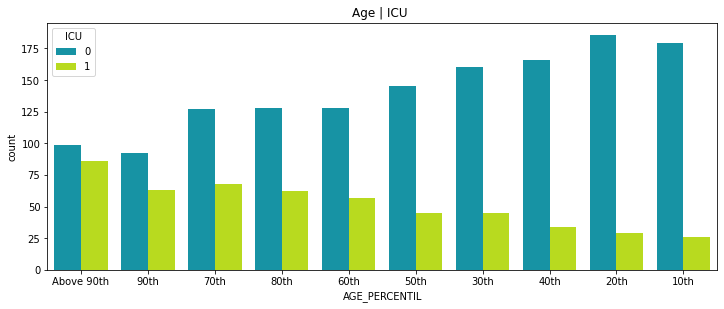

```python
# age / ICU admin
plt.figure(figsize=(12,10))
plt.subplot(2,1,1)
plt.title('Age | ICU ')
sort=data[['AGE_PERCENTIL', 'ICU']].groupby(['AGE_PERCENTIL'],as_index=False).mean()
sort.sort_values(by='ICU', ascending=False, inplace=True)
sns.countplot(data['AGE_PERCENTIL'], hue='ICU', data=data, palette='nipy_spectral', order=sort['AGE_PERCENTIL'])
```

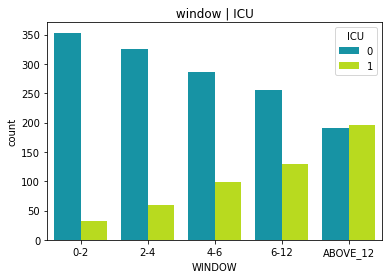

```python
# window / ICU adm
plt.figure()
plt.title(' window | ICU ')
sns.countplot(data['WINDOW'], hue='ICU', data=data, palette='nipy_spectral')
plt.show()
```

Obs:

- 1st graph - we can observe that the number of ICU admissions is higher as the percentil of age goes up as well. Patients with age above 90 have almost a 50/50 chance of being admitted to the ICU.
- 2nd graph - we observe that the percentage of ICU admissions goes up as the window of hours since admission into the hospital increase, which is expected.

### Real (interval) features

```python
real = meta2[(meta2.type == 'real') & (meta2.preserve)].index
data[real].describe()
```

|  | ALBUMIN_MEDIAN | ALBUMIN_MEAN | ALBUMIN_MIN | ALBUMIN_MAX | ALBUMIN_DIFF | BE_ARTERIAL_MEDIAN | BE_ARTERIAL_MEAN | BE_ARTERIAL_MIN | BE_ARTERIAL_MAX | BE_ARTERIAL_DIFF | BE_VENOUS_MEDIAN | BE_VENOUS_MEAN | BE_VENOUS_MIN | BE_VENOUS_MAX | BE_VENOUS_DIFF | BIC_ARTERIAL_MEDIAN | BIC_ARTERIAL_MEAN | BIC_ARTERIAL_MIN | BIC_ARTERIAL_MAX | BIC_ARTERIAL_DIFF | BIC_VENOUS_MEDIAN | BIC_VENOUS_MEAN | BIC_VENOUS_MIN | BIC_VENOUS_MAX | BIC_VENOUS_DIFF | BILLIRUBIN_MEDIAN | BILLIRUBIN_MEAN | BILLIRUBIN_MIN | BILLIRUBIN_MAX | … |
| --- | --- | --- | --- | --- | --- | --- | --- | --- | --- | --- | --- | --- | --- | --- | --- | --- | --- | --- | --- | --- | --- | --- | --- | --- | --- | --- | --- | --- | --- | --- |
| count | 821.000000 | 821.000000 | 821.000000 | 821.000000 | 821.0 | 821.000000 | 821.000000 | 821.000000 | 821.000000 | 821.0 | 821.000000 | 821.000000 | 821.000000 | 821.000000 | 821.0 | 821.000000 | 821.000000 | 821.000000 | 821.000000 | 821.0 | 821.000000 | 821.000000 | 821.000000 | 821.000000 | 821.0 | 821.000000 | 821.000000 | 821.000000 | 821.000000 | … |
| mean | 0.528527 | 0.528527 | 0.528527 | 0.528527 | -1.0 | -0.963433 | -0.963433 | -0.963433 | -0.963433 | -1.0 | -0.931121 | -0.931121 | -0.931121 | -0.931121 | -1.0 | -0.310924 | -0.310924 | -0.310924 | -0.310924 | -1.0 | -0.311845 | -0.311845 | -0.311845 | -0.311845 | -1.0 | -0.945928 | -0.945928 | -0.945928 | -0.945928 | … |
| std | 0.224100 | 0.224100 | 0.224100 | 0.224100 | 0.0 | 0.160870 | 0.160870 | 0.160870 | 0.160870 | 0.0 | 0.169509 | 0.169509 | 0.169509 | 0.169509 | 0.0 | 0.100256 | 0.100256 | 0.100256 | 0.100256 | 0.0 | 0.118812 | 0.118812 | 0.118812 | 0.118812 | 0.0 | 0.076610 | 0.076610 | 0.076610 | 0.076610 | … |
| min | -1.000000 | -1.000000 | -1.000000 | -1.000000 | -1.0 | -1.000000 | -1.000000 | -1.000000 | -1.000000 | -1.0 | -1.000000 | -1.000000 | -1.000000 | -1.000000 | -1.0 | -1.000000 | -1.000000 | -1.000000 | -1.000000 | -1.0 | -1.000000 | -1.000000 | -1.000000 | -1.000000 | -1.0 | -1.000000 | -1.000000 | -1.000000 | -1.000000 | … |
| 25% | 0.605263 | 0.605263 | 0.605263 | 0.605263 | -1.0 | -1.000000 | -1.000000 | -1.000000 | -1.000000 | -1.0 | -1.000000 | -1.000000 | -1.000000 | -1.000000 | -1.0 | -0.317073 | -0.317073 | -0.317073 | -0.317073 | -1.0 | -0.317073 | -0.317073 | -0.317073 | -0.317073 | -1.0 | -0.966510 | -0.966510 | -0.966510 | -0.966510 | … |
| 50% | 0.605263 | 0.605263 | 0.605263 | 0.605263 | -1.0 | -1.000000 | -1.000000 | -1.000000 | -1.000000 | -1.0 | -1.000000 | -1.000000 | -1.000000 | -1.000000 | -1.0 | -0.317073 | -0.317073 | -0.317073 | -0.317073 | -1.0 | -0.317073 | -0.317073 | -0.317073 | -0.317073 | -1.0 | -0.938950 | -0.938950 | -0.938950 | -0.938950 | … |
| 75% | 0.605263 | 0.605263 | 0.605263 | 0.605263 | -1.0 | -1.000000 | -1.000000 | -1.000000 | -1.000000 | -1.0 | -0.958115 | -0.958115 | -0.958115 | -0.958115 | -1.0 | -0.317073 | -0.317073 | -0.317073 | -0.317073 | -1.0 | -0.317073 | -0.317073 | -0.317073 | -0.317073 | -1.0 | -0.938950 | -0.938950 | -0.938950 | -0.938950 | … |
| max | 1.000000 | 1.000000 | 1.000000 | 1.000000 | -1.0 | 1.000000 | 1.000000 | 1.000000 | 1.000000 | -1.0 | 1.000000 | 1.000000 | 1.000000 | 1.000000 | -1.0 | 1.000000 | 1.000000 | 1.000000 | 1.000000 | -1.0 | 1.000000 | 1.000000 | 1.000000 | 1.000000 | -1.0 | 1.000000 | 1.000000 | 1.000000 | 1.000000 | … |

## Bivariate Exploration

### Real (interval) features

We will visualise the relationship between features in the real variables using correlation matrix

```python
variable = meta2[(meta2.type == 'real') & (meta2.preserve)].index
data[variable].describe()
```

|  | ALBUMIN_MEDIAN | ALBUMIN_MEAN | ALBUMIN_MIN | ALBUMIN_MAX | ALBUMIN_DIFF | BE_ARTERIAL_MEDIAN | BE_ARTERIAL_MEAN | BE_ARTERIAL_MIN | BE_ARTERIAL_MAX | BE_ARTERIAL_DIFF | BE_VENOUS_MEDIAN | BE_VENOUS_MEAN | BE_VENOUS_MIN | BE_VENOUS_MAX | BE_VENOUS_DIFF | BIC_ARTERIAL_MEDIAN | BIC_ARTERIAL_MEAN | BIC_ARTERIAL_MIN | BIC_ARTERIAL_MAX | BIC_ARTERIAL_DIFF | BIC_VENOUS_MEDIAN | BIC_VENOUS_MEAN | BIC_VENOUS_MIN | BIC_VENOUS_MAX | BIC_VENOUS_DIFF | BILLIRUBIN_MEDIAN | BILLIRUBIN_MEAN | BILLIRUBIN_MIN | BILLIRUBIN_MAX | … |
| --- | --- | --- | --- | --- | --- | --- | --- | --- | --- | --- | --- | --- | --- | --- | --- | --- | --- | --- | --- | --- | --- | --- | --- | --- | --- | --- | --- | --- | --- | --- |
| count | 821.000000 | 821.000000 | 821.000000 | 821.000000 | 821.0 | 821.000000 | 821.000000 | 821.000000 | 821.000000 | 821.0 | 821.000000 | 821.000000 | 821.000000 | 821.000000 | 821.0 | 821.000000 | 821.000000 | 821.000000 | 821.000000 | 821.0 | 821.000000 | 821.000000 | 821.000000 | 821.000000 | 821.0 | 821.000000 | 821.000000 | 821.000000 | 821.000000 | … |
| mean | 0.528527 | 0.528527 | 0.528527 | 0.528527 | -1.0 | -0.963433 | -0.963433 | -0.963433 | -0.963433 | -1.0 | -0.931121 | -0.931121 | -0.931121 | -0.931121 | -1.0 | -0.310924 | -0.310924 | -0.310924 | -0.310924 | -1.0 | -0.311845 | -0.311845 | -0.311845 | -0.311845 | -1.0 | -0.945928 | -0.945928 | -0.945928 | -0.945928 | … |
| std | 0.224100 | 0.224100 | 0.224100 | 0.224100 | 0.0 | 0.160870 | 0.160870 | 0.160870 | 0.160870 | 0.0 | 0.169509 | 0.169509 | 0.169509 | 0.169509 | 0.0 | 0.100256 | 0.100256 | 0.100256 | 0.100256 | 0.0 | 0.118812 | 0.118812 | 0.118812 | 0.118812 | 0.0 | 0.076610 | 0.076610 | 0.076610 | 0.076610 | … |
| min | -1.000000 | -1.000000 | -1.000000 | -1.000000 | -1.0 | -1.000000 | -1.000000 | -1.000000 | -1.000000 | -1.0 | -1.000000 | -1.000000 | -1.000000 | -1.000000 | -1.0 | -1.000000 | -1.000000 | -1.000000 | -1.000000 | -1.0 | -1.000000 | -1.000000 | -1.000000 | -1.000000 | -1.0 | -1.000000 | -1.000000 | -1.000000 | -1.000000 | … |
| 25% | 0.605263 | 0.605263 | 0.605263 | 0.605263 | -1.0 | -1.000000 | -1.000000 | -1.000000 | -1.000000 | -1.0 | -1.000000 | -1.000000 | -1.000000 | -1.000000 | -1.0 | -0.317073 | -0.317073 | -0.317073 | -0.317073 | -1.0 | -0.317073 | -0.317073 | -0.317073 | -0.317073 | -1.0 | -0.966510 | -0.966510 | -0.966510 | -0.966510 | … |
| 50% | 0.605263 | 0.605263 | 0.605263 | 0.605263 | -1.0 | -1.000000 | -1.000000 | -1.000000 | -1.000000 | -1.0 | -1.000000 | -1.000000 | -1.000000 | -1.000000 | -1.0 | -0.317073 | -0.317073 | -0.317073 | -0.317073 | -1.0 | -0.317073 | -0.317073 | -0.317073 | -0.317073 | -1.0 | -0.938950 | -0.938950 | -0.938950 | -0.938950 | … |
| 75% | 0.605263 | 0.605263 | 0.605263 | 0.605263 | -1.0 | -1.000000 | -1.000000 | -1.000000 | -1.000000 | -1.0 | -0.958115 | -0.958115 | -0.958115 | -0.958115 | -1.0 | -0.317073 | -0.317073 | -0.317073 | -0.317073 | -1.0 | -0.317073 | -0.317073 | -0.317073 | -0.317073 | -1.0 | -0.938950 | -0.938950 | -0.938950 | -0.938950 | … |
| max | 1.000000 | 1.000000 | 1.000000 | 1.000000 | -1.0 | 1.000000 | 1.000000 | 1.000000 | 1.000000 | -1.0 | 1.000000 | 1.000000 | 1.000000 | 1.000000 | -1.0 | 1.000000 | 1.000000 | 1.000000 | 1.000000 | -1.0 | 1.000000 | 1.000000 | 1.000000 | 1.000000 | -1.0 | 1.000000 | 1.000000 | 1.000000 | 1.000000 | … |

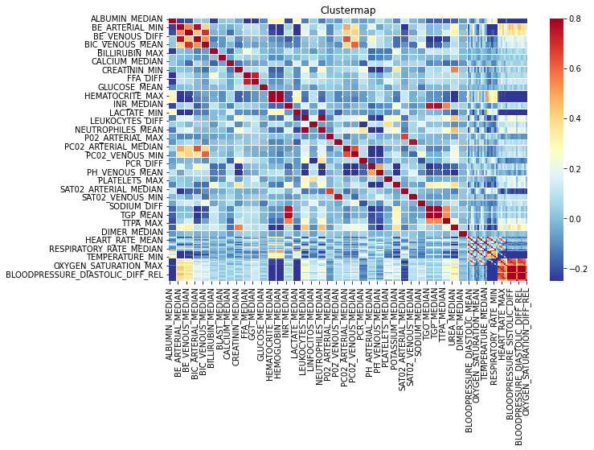

```python
# Heatmap of correlation between all features
corrs = data[variable].corr()
plt.figure(figsize = (10, 6))
sns.heatmap(corrs, cmap = plt.cm.RdYlBu_r, vmin = -0.25, annot = False, vmax = 0.8)
plt.title('Clustermap');
```

Because there is a lot o features it's hard to take important information from the graph above.

Lets check the correlation between the features and the ICU column:

```python
data_target_corr = abs(data.corr()['ICU'])

data_target_corr[data_target_corr < 1].sort_values(ascending = False)
```

```
RESPIRATORY_RATE_MAX                0.588523
RESPIRATORY_RATE_DIFF               0.502663
RESPIRATORY_RATE_DIFF_REL           0.489765
LACTATE_MIN                         0.482143
LACTATE_MEAN                        0.482143
LACTATE_MEDIAN                      0.482143
LACTATE_MAX                         0.482143
RESPIRATORY_RATE_MEAN               0.428144
BLOODPRESSURE_SISTOLIC_DIFF         0.413082
BLOODPRESSURE_DIASTOLIC_MIN         0.405757
BLOODPRESSURE_SISTOLIC_DIFF_REL     0.403476
RESPIRATORY_RATE_MEDIAN             0.387823
BLOODPRESSURE_SISTOLIC_MAX          0.379264
BLOODPRESSURE_DIASTOLIC_DIFF_REL    0.376300
BLOODPRESSURE_DIASTOLIC_DIFF        0.361708
HEART_RATE_DIFF                     0.335091
HEART_RATE_DIFF_REL                 0.333011
TEMPERATURE_DIFF_REL                0.331295
TEMPERATURE_DIFF                    0.330577
BE_VENOUS_MIN                       0.315695
BE_VENOUS_MEAN                      0.315695
BE_VENOUS_MEDIAN                    0.315695
BE_VENOUS_MAX                       0.315695
HEMOGLOBIN_MAX                      0.299909
HEMOGLOBIN_MIN                      0.299909
HEMOGLOBIN_MEAN                     0.299909
HEMOGLOBIN_MEDIAN                   0.299909
BE_ARTERIAL_MEAN                    0.298721
BE_ARTERIAL_MIN                     0.298721
BE_ARTERIAL_MAX                     0.298721
BE_ARTERIAL_MEDIAN                  0.298721
TEMPERATURE_MIN                     0.289717
LEUKOCYTES_MIN                      0.287159
LEUKOCYTES_MAX                      0.287159
LEUKOCYTES_MEAN                     0.287159
LEUKOCYTES_MEDIAN                   0.287159
HEMATOCRITE_MAX                     0.283485
HEMATOCRITE_MEAN                    0.283485
HEMATOCRITE_MIN                     0.283485
HEMATOCRITE_MEDIAN                  0.283485
```

[output cut: 138 more lines]

```
OXYGEN_SATURATION_MEDIAN            0.019525
BLAST_MIN                           0.018549
BLAST_MAX                           0.018549
BLAST_MEDIAN                        0.018549
BLAST_MEAN                          0.018549
HEART_RATE_MEDIAN                   0.016677
IMMUNOCOMPROMISED                   0.014357
GLUCOSE_MIN                         0.011992
GLUCOSE_MEAN                        0.011992
GLUCOSE_MEDIAN                      0.011992
GLUCOSE_MAX                         0.011992
DISEASE GROUPING 6                  0.006344
OXYGEN_SATURATION_MEAN              0.005636
HEART_RATE_MEAN                     0.001294
Name: ICU, dtype: float64
```

# Data Preparation

```python
# Make a copy of the data
data_copy = data.copy()
```

```python
# create column to identify if patient ever went to ICU
clean_data = (data.groupby("PATIENT_VISIT_IDENTIFIER")["ICU"].sum()>0).reset_index()*1
clean_data.columns = ["PATIENT_VISIT_IDENTIFIER", "ICU_SUM"]
clean_data = pd.merge(data, clean_data, on = "PATIENT_VISIT_IDENTIFIER")
clean_data.head()
```

|  | PATIENT_VISIT_IDENTIFIER | AGE_ABOVE65 | AGE_PERCENTIL | GENDER | DISEASE GROUPING 1 | DISEASE GROUPING 2 | DISEASE GROUPING 3 | DISEASE GROUPING 4 | DISEASE GROUPING 5 | DISEASE GROUPING 6 | HTN | IMMUNOCOMPROMISED | OTHER | ALBUMIN_MEDIAN | ALBUMIN_MEAN | ALBUMIN_MIN | ALBUMIN_MAX | ALBUMIN_DIFF | BE_ARTERIAL_MEDIAN | BE_ARTERIAL_MEAN | BE_ARTERIAL_MIN | BE_ARTERIAL_MAX | BE_ARTERIAL_DIFF | BE_VENOUS_MEDIAN | BE_VENOUS_MEAN | BE_VENOUS_MIN | BE_VENOUS_MAX | BE_VENOUS_DIFF | BIC_ARTERIAL_MEDIAN | … |
| --- | --- | --- | --- | --- | --- | --- | --- | --- | --- | --- | --- | --- | --- | --- | --- | --- | --- | --- | --- | --- | --- | --- | --- | --- | --- | --- | --- | --- | --- | --- |
| 0 | 0 | 1 | 60th | 0 | 0.0 | 0.0 | 0.0 | 0.0 | 1.0 | 1.0 | 0.0 | 0.0 | 1.0 | NaN | NaN | NaN | NaN | NaN | NaN | NaN | NaN | NaN | NaN | NaN | NaN | NaN | NaN | NaN | NaN | … |
| 1 | 0 | 1 | 60th | 0 | 0.0 | 0.0 | 0.0 | 0.0 | 1.0 | 1.0 | 0.0 | 0.0 | 1.0 | NaN | NaN | NaN | NaN | NaN | NaN | NaN | NaN | NaN | NaN | NaN | NaN | NaN | NaN | NaN | NaN | … |
| 2 | 0 | 1 | 60th | 0 | 0.0 | 0.0 | 0.0 | 0.0 | 1.0 | 1.0 | 0.0 | 0.0 | 1.0 | 0.605263 | 0.605263 | 0.605263 | 0.605263 | -1.0 | -1.000000 | -1.000000 | -1.000000 | -1.000000 | -1.0 | -1.000000 | -1.000000 | -1.000000 | -1.000000 | -1.0 | -0.317073 | … |
| 3 | 0 | 1 | 60th | 0 | 0.0 | 0.0 | 0.0 | 0.0 | 1.0 | 1.0 | 0.0 | 0.0 | 1.0 | NaN | NaN | NaN | NaN | NaN | NaN | NaN | NaN | NaN | NaN | NaN | NaN | NaN | NaN | NaN | NaN | … |
| 4 | 0 | 1 | 60th | 0 | 0.0 | 0.0 | 0.0 | 0.0 | 1.0 | 1.0 | 0.0 | 0.0 | 1.0 | 0.000000 | 0.000000 | 0.000000 | 0.000000 | -1.0 | -0.871658 | -0.871658 | -0.871658 | -0.871658 | -1.0 | -0.863874 | -0.863874 | -0.863874 | -0.863874 | -1.0 | -0.317073 | … |

## Data Cleaning

As we observed before, in the missing values step there are 225 variables with missing values and in total, 223863 NaN values.

We will deal with this by inputing the values with the next and previous values, as sugested by the authors of the dataset.

```python
clean_data=clean_data.fillna(method='ffill').fillna(method='bfill') # filling of NaNs
clean_data.head()
```

|  | PATIENT_VISIT_IDENTIFIER | AGE_ABOVE65 | AGE_PERCENTIL | GENDER | DISEASE GROUPING 1 | DISEASE GROUPING 2 | DISEASE GROUPING 3 | DISEASE GROUPING 4 | DISEASE GROUPING 5 | DISEASE GROUPING 6 | HTN | IMMUNOCOMPROMISED | OTHER | ALBUMIN_MEDIAN | ALBUMIN_MEAN | ALBUMIN_MIN | ALBUMIN_MAX | ALBUMIN_DIFF | BE_ARTERIAL_MEDIAN | BE_ARTERIAL_MEAN | BE_ARTERIAL_MIN | BE_ARTERIAL_MAX | BE_ARTERIAL_DIFF | BE_VENOUS_MEDIAN | BE_VENOUS_MEAN | BE_VENOUS_MIN | BE_VENOUS_MAX | BE_VENOUS_DIFF | BIC_ARTERIAL_MEDIAN | … |
| --- | --- | --- | --- | --- | --- | --- | --- | --- | --- | --- | --- | --- | --- | --- | --- | --- | --- | --- | --- | --- | --- | --- | --- | --- | --- | --- | --- | --- | --- | --- |
| 0 | 0 | 1 | 60th | 0 | 0.0 | 0.0 | 0.0 | 0.0 | 1.0 | 1.0 | 0.0 | 0.0 | 1.0 | 0.605263 | 0.605263 | 0.605263 | 0.605263 | -1.0 | -1.000000 | -1.000000 | -1.000000 | -1.000000 | -1.0 | -1.000000 | -1.000000 | -1.000000 | -1.000000 | -1.0 | -0.317073 | … |
| 1 | 0 | 1 | 60th | 0 | 0.0 | 0.0 | 0.0 | 0.0 | 1.0 | 1.0 | 0.0 | 0.0 | 1.0 | 0.605263 | 0.605263 | 0.605263 | 0.605263 | -1.0 | -1.000000 | -1.000000 | -1.000000 | -1.000000 | -1.0 | -1.000000 | -1.000000 | -1.000000 | -1.000000 | -1.0 | -0.317073 | … |
| 2 | 0 | 1 | 60th | 0 | 0.0 | 0.0 | 0.0 | 0.0 | 1.0 | 1.0 | 0.0 | 0.0 | 1.0 | 0.605263 | 0.605263 | 0.605263 | 0.605263 | -1.0 | -1.000000 | -1.000000 | -1.000000 | -1.000000 | -1.0 | -1.000000 | -1.000000 | -1.000000 | -1.000000 | -1.0 | -0.317073 | … |
| 3 | 0 | 1 | 60th | 0 | 0.0 | 0.0 | 0.0 | 0.0 | 1.0 | 1.0 | 0.0 | 0.0 | 1.0 | 0.605263 | 0.605263 | 0.605263 | 0.605263 | -1.0 | -1.000000 | -1.000000 | -1.000000 | -1.000000 | -1.0 | -1.000000 | -1.000000 | -1.000000 | -1.000000 | -1.0 | -0.317073 | … |
| 4 | 0 | 1 | 60th | 0 | 0.0 | 0.0 | 0.0 | 0.0 | 1.0 | 1.0 | 0.0 | 0.0 | 1.0 | 0.000000 | 0.000000 | 0.000000 | 0.000000 | -1.0 | -0.871658 | -0.871658 | -0.871658 | -0.871658 | -1.0 | -0.863874 | -0.863874 | -0.863874 | -0.863874 | -1.0 | -0.317073 | … |

## Dropping Columns and Rows

```python
#Rows with ICU = 1 will be dropped because they are not usefull for our model as stipulated by the author
final_data= clean_data[clean_data.ICU == 0].reset_index(drop= True)
```

```python
#We will use window 0-2 data on our model to predict as soon as possible if the patient will have to be admitted to the ICU, as recomended by the authors
final_data = final_data[final_data.WINDOW == "0-2"].reset_index(drop = True)
```

```python
#drop patient ID, window and ICU columns
final= final_data.drop(["PATIENT_VISIT_IDENTIFIER", "WINDOW", "ICU"],axis = 1)
```

```python
# Feature Encoding
le = LabelEncoder()
final['AGE_PERCENTIL'] = le.fit_transform(final['AGE_PERCENTIL'])
```

```python
final.duplicated().sum()
```

```
0
```

```python
data.shape
```

```
(1925, 231)
```

```python
final.shape
```

```
(353, 229)
```

1572 rows and 2 columns have been droped

```python
final.head()
```

|  | AGE_ABOVE65 | AGE_PERCENTIL | GENDER | DISEASE GROUPING 1 | DISEASE GROUPING 2 | DISEASE GROUPING 3 | DISEASE GROUPING 4 | DISEASE GROUPING 5 | DISEASE GROUPING 6 | HTN | IMMUNOCOMPROMISED | OTHER | ALBUMIN_MEDIAN | ALBUMIN_MEAN | ALBUMIN_MIN | ALBUMIN_MAX | ALBUMIN_DIFF | BE_ARTERIAL_MEDIAN | BE_ARTERIAL_MEAN | BE_ARTERIAL_MIN | BE_ARTERIAL_MAX | BE_ARTERIAL_DIFF | BE_VENOUS_MEDIAN | BE_VENOUS_MEAN | BE_VENOUS_MIN | BE_VENOUS_MAX | BE_VENOUS_DIFF | BIC_ARTERIAL_MEDIAN | BIC_ARTERIAL_MEAN | … |
| --- | --- | --- | --- | --- | --- | --- | --- | --- | --- | --- | --- | --- | --- | --- | --- | --- | --- | --- | --- | --- | --- | --- | --- | --- | --- | --- | --- | --- | --- | --- |
| 0 | 1 | 5 | 0 | 0.0 | 0.0 | 0.0 | 0.0 | 1.0 | 1.0 | 0.0 | 0.0 | 1.0 | 0.605263 | 0.605263 | 0.605263 | 0.605263 | -1.0 | -1.0 | -1.0 | -1.0 | -1.0 | -1.0 | -1.0 | -1.0 | -1.0 | -1.0 | -1.0 | -0.317073 | -0.317073 | … |
| 1 | 0 | 0 | 0 | 0.0 | 0.0 | 0.0 | 0.0 | 0.0 | 0.0 | 0.0 | 0.0 | 1.0 | 0.605263 | 0.605263 | 0.605263 | 0.605263 | -1.0 | -1.0 | -1.0 | -1.0 | -1.0 | -1.0 | -1.0 | -1.0 | -1.0 | -1.0 | -1.0 | -0.317073 | -0.317073 | … |
| 2 | 0 | 3 | 1 | 0.0 | 0.0 | 0.0 | 0.0 | 0.0 | 0.0 | 0.0 | 1.0 | 1.0 | 0.605263 | 0.605263 | 0.605263 | 0.605263 | -1.0 | -1.0 | -1.0 | -1.0 | -1.0 | -1.0 | -1.0 | -1.0 | -1.0 | -1.0 | -1.0 | -0.317073 | -0.317073 | … |
| 3 | 0 | 0 | 0 | 0.0 | 0.0 | 0.0 | 0.0 | 0.0 | 0.0 | 0.0 | 0.0 | 1.0 | 0.605263 | 0.605263 | 0.605263 | 0.605263 | -1.0 | -1.0 | -1.0 | -1.0 | -1.0 | -1.0 | -1.0 | -1.0 | -1.0 | -1.0 | -1.0 | -0.317073 | -0.317073 | … |
| 4 | 0 | 0 | 0 | 0.0 | 0.0 | 0.0 | 0.0 | 0.0 | 0.0 | 0.0 | 0.0 | 1.0 | 0.605263 | 0.605263 | 0.605263 | 0.605263 | -1.0 | -1.0 | -1.0 | -1.0 | -1.0 | -1.0 | -1.0 | -1.0 | -1.0 | -1.0 | -1.0 | -0.317073 | -0.317073 | … |

```python
data = final
```

# ML Model Comparison

```python
def cv_model(data: pd.DataFrame, y='ICU_SUM', x_drop=['ICU_SUM'],
          model=DecisionTreeClassifier(), n_splits=5, n_repeats=10,
          description_model='Decision Tree Classifier'):

  np.random.seed(8)
  data = data.sample(frac=1).reset_index(drop=True)
  y = data[y]
  x = data.drop(x_drop, axis=1)

  model = model
  cv = RepeatedStratifiedKFold(n_splits=n_splits, n_repeats=n_repeats)
  result = cross_validate(model, x, y, cv=cv, scoring='roc_auc', return_train_score=True)

  mean_test = np.mean(result['test_score'])
  mean_train = np.mean(result['train_score'])

  print(f'AUC test/ train: {mean_test:.2f} - {mean_train:.2f}')

  return mean_test, mean_train
```

```python
#Plot the graph with train and test AUC

def curve_auc(mean_test: list(), mean_train: list(), description_model: str,
              n_repeats_x=10):

  x = range(1, n_repeats_x)
  plt.figure(figsize=(16, 8))
  plt.plot(x, mean_test, label='AUC Test', )
  plt.plot(x, mean_train, label='AUC Train')
  plt.title(description_model, loc='left', fontsize=24)
  plt.legend();
```

## Logistic Regression

```python
cv_model(data, model=LogisticRegression(max_iter=300),
                 description_model='Logistic Regression')
```

```
AUC test/ train: 0.69 - 0.84
```

```
(0.6853548644338118, 0.8366514819049975)
```

## Decision Tree Classifier

```python
cv_model(data)
```

```
AUC test/ train: 0.62 - 1.00
```

```
(0.6154385964912281, 1.0)
```

```python
# auc_test_tree: List with the result of mean AUC of test data for each node of the dt model
#auc_treino_tree: List with the result of mean AUC of train data for each node of the dt model

auc_test_tree = list()
auc_train_tree = list()
for i in range(1, 10):
  test, train = cv_model(data, model=DecisionTreeClassifier(max_depth=i),
                 description_model='Decision Tree Classifier')
  auc_test_tree.append(test)
  auc_train_tree.append(train)
```

```
AUC test/ train: 0.63 - 0.65
AUC test/ train: 0.66 - 0.74
AUC test/ train: 0.66 - 0.80
AUC test/ train: 0.65 - 0.86
AUC test/ train: 0.63 - 0.90
AUC test/ train: 0.62 - 0.94
AUC test/ train: 0.60 - 0.96
AUC test/ train: 0.60 - 0.98
AUC test/ train: 0.59 - 0.98
```

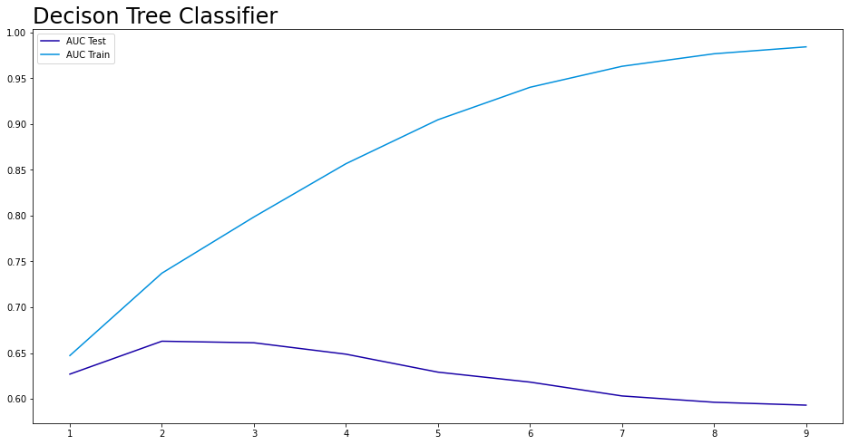

```python
curve_auc(auc_test_tree, auc_train_tree, 'Decison Tree Classifier')
```

## Random Forest Classifier

```python
cv_model(data, model=RandomForestClassifier())
```

```
AUC test/ train: 0.67 - 1.00
```

```
(0.6744355562200959, 1.0)
```

```python
# auc_test_rf: List with the result of mean AUC of test data for each node of the rf model
# auc_train_rf: List with the result of mean AUC of test data for each node of the rf model

auc_test_rf = list()
auc_train_rf = list()
for i in range(1, 10):
  test, train = cv_model(data, model=RandomForestClassifier(max_depth=i),
                 description_model='Random Forest Classifier')
  auc_test_rf.append(test)
  auc_train_rf.append(train)
```

```
AUC test/ train: 0.68 - 0.80
AUC test/ train: 0.69 - 0.86
AUC test/ train: 0.69 - 0.92
AUC test/ train: 0.69 - 0.96
AUC test/ train: 0.69 - 0.99
AUC test/ train: 0.68 - 1.00
AUC test/ train: 0.69 - 1.00
AUC test/ train: 0.69 - 1.00
AUC test/ train: 0.68 - 1.00
```

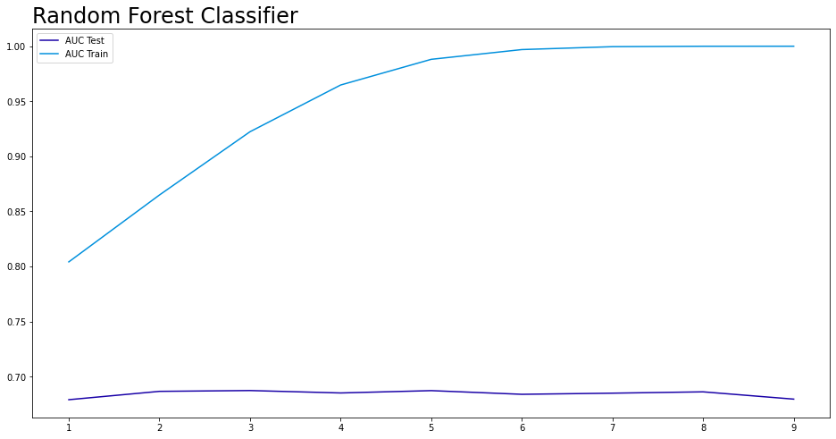

```python
curve_auc(auc_test_rf, auc_train_rf, 'Random Forest Classifier')
```

## SVM

```python
cv_model(data, model=SVC())
```

```
AUC test/ train: 0.72 - 0.78
```

```
(0.7215296052631579, 0.7786115832740984)
```

1. Logistic Regression - AUC test/ train: 0.69 - 0.84
2. Decision Tree Classifier - AUC test/ train: 0.62 - 1.00
3. Random Forest - AUC test/ train: 0.67 - 1.00
4. Suport Vector Machine - AUC test/ train: 0.72 - 0.78

**SVM** is the model that has the best AUC value.

# Analysing the best model: SVM

```python
def model_train_test(data: pd.DataFrame, y='ICU_SUM', x_drop=['ICU_SUM'],
                        model=SVC()):


  seed = np.random.seed(1)
  data = data.sample(frac=1).reset_index(drop=True)
  y = data[y]
  x = data.drop(x_drop, axis=1)

  x_train, x_test, y_train, y_test = train_test_split(x, y, test_size=.3, random_state=seed, stratify=y)
  model.fit(x_train, y_train)
  y_predicted = model.predict(x_test)

  return model, x_train, x_test, y_train, y_test, y_predicted
```

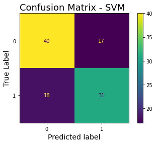

```python
model_svm, x_train_1, x_test_1, y_train_1, y_test_1, y_predicted_1 = model_train_test(data, model=SVC())

# Plot confusion matrix SVM model

plot_confusion_matrix(model_svm, x_test_1, y_test_1)

plt.title("Confusion Matrix - SVM", loc='left', fontsize=18)
plt.xlabel("Predicted label", fontsize=14)
plt.ylabel("True Label", fontsize=14)
```

```python
print(classification_report(y_test_1, y_predicted_1))
```

```
              precision    recall  f1-score   support

           0       0.69      0.70      0.70        57
           1       0.65      0.63      0.64        49

    accuracy                           0.67       106
   macro avg       0.67      0.67      0.67       106
weighted avg       0.67      0.67      0.67       106
```